# 🛡️ MindGuard — Crisis Detection Evaluation

This notebook performs a comprehensive evaluation of the crisis detection system:

1. Load VAE reconstruction errors and threshold data
2. Compare VAE anomaly detector vs keyword baseline
3. Analyze the dual detection (VAE ∪ Keyword) safety policy
4. Generate publication-quality figures for the report

### Figures generated

- Reconstruction error distribution (crisis vs non-crisis)
- VAE vs Keyword metrics comparison
- Threshold sensitivity analysis (ROC-like curve)
- Confusion matrices for all 3 methods
- Dual detection Venn analysis
- Error percentile analysis

## 1. Setup & Load Data

```python
import json
import warnings
from pathlib import Path

import matplotlib.pyplot as plt
import matplotlib.ticker as mticker
import numpy as np
import pandas as pd
import seaborn as sns

warnings.filterwarnings("ignore", category=FutureWarning)

# Paths
EVAL_DIR = Path("../data/processed/evaluation")
ERRORS_PATH = Path("../models/vae_crisis/reconstruction_errors.csv")
SUMMARY_PATH = Path("../data/processed/vae_threshold_summary.json")
OUTPUT_DIR = EVAL_DIR
OUTPUT_DIR.mkdir(parents=True, exist_ok=True)

# Style
plt.rcParams.update({
    "figure.dpi": 150,
    "font.size": 11,
    "axes.titlesize": 13,
    "axes.labelsize": 11,
    "figure.facecolor": "white",
})

print("✅ Setup complete")
```

```
✅ Setup complete
```

```python
# Load reconstruction errors
df = pd.read_csv(ERRORS_PATH)
print(f"Total samples: {len(df):,}")
print(f"Columns: {list(df.columns)}")
print(f"\nClass distribution:")
print(df["is_crisis"].value_counts().rename({0: "Non-crisis", 1: "Crisis"}))

# Load threshold summary
summary = json.loads(SUMMARY_PATH.read_text(encoding="utf-8"))
threshold = summary["threshold"]["value"]
vae_metrics = summary["metrics"]
kw_metrics = summary["keyword_baseline_metrics"]

print(f"\nVAE threshold: {threshold:.6f}")
print(f"VAE — P: {vae_metrics['precision']:.4f}, R: {vae_metrics['recall']:.4f}, F1: {vae_metrics['f1']:.4f}")
print(f"KW  — P: {kw_metrics['precision']:.4f}, R: {kw_metrics['recall']:.4f}, F1: {kw_metrics['f1']:.4f}")
```

```
Total samples: 10,000
Columns: ['text', 'is_crisis', 'reconstruction_error', 'predicted_crisis']

Class distribution:
is_crisis
Non-crisis    5000
Crisis        5000
Name: count, dtype: int64

VAE threshold: 0.000497
VAE — P: 0.4615, R: 0.0324, F1: 0.0605
KW  — P: 0.8680, R: 0.3524, F1: 0.5013
```

## 2. Add Keyword Baseline Predictions

```python
CRISIS_MARKERS = {
    "suicide", "kill myself", "end my life", "self harm",
    "can't go on", "cannot go on", "want to die", "no reason to live",
}

df["keyword_predicted"] = df["text"].apply(
    lambda t: int(any(m in str(t).lower() for m in CRISIS_MARKERS))
)

# Dual detection: crisis if EITHER VAE or keyword triggers
df["combined_predicted"] = ((df["predicted_crisis"] == 1) | (df["keyword_predicted"] == 1)).astype(int)

y_true = df["is_crisis"].to_numpy()
y_vae = df["predicted_crisis"].to_numpy()
y_kw = df["keyword_predicted"].to_numpy()
y_combined = df["combined_predicted"].to_numpy()
errors = df["reconstruction_error"].to_numpy()

print("Prediction counts:")
print(f"  VAE flagged:      {y_vae.sum():,}")
print(f"  Keyword flagged:  {y_kw.sum():,}")
print(f"  Combined flagged: {y_combined.sum():,}")
```

```
Prediction counts:
  VAE flagged:      351
  Keyword flagged:  2,030
  Combined flagged: 2,313
```

## 3. Full Metrics Comparison

```python
from sklearn.metrics import precision_score, recall_score, f1_score, accuracy_score

def compute_metrics(y_true, y_pred, method_name):
    tp = int(((y_true == 1) & (y_pred == 1)).sum())
    fp = int(((y_true == 0) & (y_pred == 1)).sum())
    fn = int(((y_true == 1) & (y_pred == 0)).sum())
    tn = int(((y_true == 0) & (y_pred == 0)).sum())
    return {
        "Method": method_name,
        "Precision": precision_score(y_true, y_pred, zero_division=0),
        "Recall": recall_score(y_true, y_pred, zero_division=0),
        "F1": f1_score(y_true, y_pred, zero_division=0),
        "Accuracy": accuracy_score(y_true, y_pred),
        "TP": tp, "FP": fp, "FN": fn, "TN": tn,
    }

results = pd.DataFrame([
    compute_metrics(y_true, y_vae, "VAE (Anomaly)"),
    compute_metrics(y_true, y_kw, "Keyword Baseline"),
    compute_metrics(y_true, y_combined, "Combined (VAE ∪ Keyword)"),
])
results[["Precision", "Recall", "F1", "Accuracy"]] = results[["Precision", "Recall", "F1", "Accuracy"]].round(4)

print("\n📊 Crisis Detection — Full Comparison:")
display(results)

results.to_csv(OUTPUT_DIR / "crisis_full_comparison.csv", index=False)
print(f"\n💾 Saved: {OUTPUT_DIR / 'crisis_full_comparison.csv'}")
```

```
📊 Crisis Detection — Full Comparison:
```

|  | Method | Precision | Recall | F1 | Accuracy | TP | FP | FN | TN |
| --- | --- | --- | --- | --- | --- | --- | --- | --- | --- |
| 0 | VAE (Anomaly) | 0.4615 | 0.0324 | 0.0605 | 0.4973 | 162 | 189 | 4838 | 4811 |
| 1 | Keyword Baseline | 0.8680 | 0.3524 | 0.5013 | 0.6494 | 1762 | 268 | 3238 | 4732 |
| 2 | Combined (VAE ∪ Keyword) | 0.8089 | 0.3742 | 0.5117 | 0.6429 | 1871 | 442 | 3129 | 4558 |

```
💾 Saved: ..\data\processed\evaluation\crisis_full_comparison.csv
```

## 4. Figures

### Figure 1: Reconstruction Error Distribution (Crisis vs Non-Crisis)

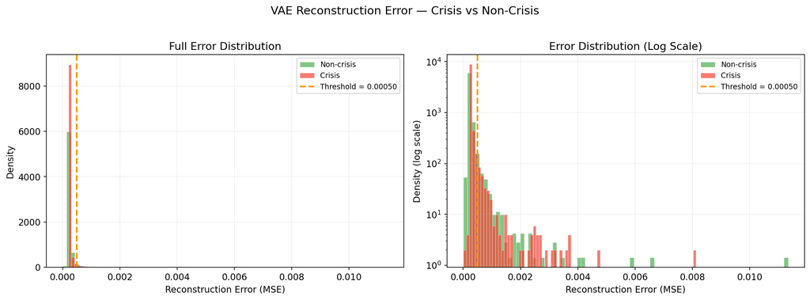

```
💾 Saved: ..\data\processed\evaluation\crisis_error_distribution.png
```

```python
crisis_errors = errors[y_true == 1]
non_crisis_errors = errors[y_true == 0]

fig, axes = plt.subplots(1, 2, figsize=(14, 5))

# Full distribution
axes[0].hist(non_crisis_errors, bins=80, alpha=0.7, label="Non-crisis",
             color="#4CAF50", density=True, edgecolor="white", linewidth=0.3)
axes[0].hist(crisis_errors, bins=80, alpha=0.7, label="Crisis",
             color="#F44336", density=True, edgecolor="white", linewidth=0.3)
axes[0].axvline(threshold, color="#FF9800", linestyle="--", linewidth=2,
                label=f"Threshold = {threshold:.5f}")
axes[0].set_xlabel("Reconstruction Error (MSE)")
axes[0].set_ylabel("Density")
axes[0].set_title("Full Error Distribution")
axes[0].legend(fontsize=9)
axes[0].grid(alpha=0.2)

# Log-scale for better tail visibility
axes[1].hist(non_crisis_errors, bins=80, alpha=0.7, label="Non-crisis",
             color="#4CAF50", density=True, edgecolor="white", linewidth=0.3)
axes[1].hist(crisis_errors, bins=80, alpha=0.7, label="Crisis",
             color="#F44336", density=True, edgecolor="white", linewidth=0.3)
axes[1].axvline(threshold, color="#FF9800", linestyle="--", linewidth=2,
                label=f"Threshold = {threshold:.5f}")
axes[1].set_xlabel("Reconstruction Error (MSE)")
axes[1].set_ylabel("Density (log scale)")
axes[1].set_title("Error Distribution (Log Scale)")
axes[1].set_yscale("log")
axes[1].legend(fontsize=9)
axes[1].grid(alpha=0.2)

fig.suptitle("VAE Reconstruction Error — Crisis vs Non-Crisis", fontsize=14, y=1.02)
fig.tight_layout()
fig.savefig(OUTPUT_DIR / "crisis_error_distribution.png", dpi=200, bbox_inches="tight")
plt.show()
print(f"💾 Saved: {OUTPUT_DIR / 'crisis_error_distribution.png'}")
```

### Figure 2: Three-Method Comparison (Grouped Bar Chart)

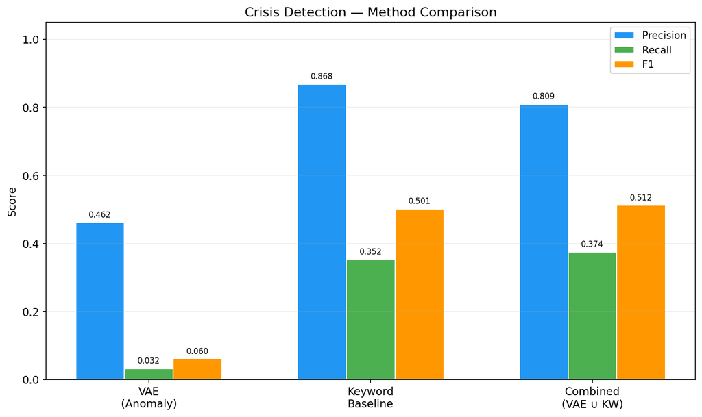

```
💾 Saved: ..\data\processed\evaluation\crisis_method_comparison.png
```

```python
methods = ["VAE\n(Anomaly)", "Keyword\nBaseline", "Combined\n(VAE ∪ KW)"]
precision_vals = results["Precision"].tolist()
recall_vals = results["Recall"].tolist()
f1_vals = results["F1"].tolist()

fig, ax = plt.subplots(figsize=(10, 6))
x = np.arange(len(methods))
width = 0.22

bars1 = ax.bar(x - width, precision_vals, width, label="Precision", color="#2196F3", edgecolor="white")
bars2 = ax.bar(x, recall_vals, width, label="Recall", color="#4CAF50", edgecolor="white")
bars3 = ax.bar(x + width, f1_vals, width, label="F1", color="#FF9800", edgecolor="white")

# Add value labels
for bars in [bars1, bars2, bars3]:
    for bar in bars:
        height = bar.get_height()
        ax.text(bar.get_x() + bar.get_width()/2., height + 0.01,
                f"{height:.3f}", ha="center", va="bottom", fontsize=8)

ax.set_xticks(x)
ax.set_xticklabels(methods, fontsize=11)
ax.set_ylabel("Score")
ax.set_ylim(0, 1.05)
ax.set_title("Crisis Detection — Method Comparison")
ax.legend(fontsize=10, loc="upper right")
ax.grid(axis="y", alpha=0.2)
fig.tight_layout()
fig.savefig(OUTPUT_DIR / "crisis_method_comparison.png", dpi=200, bbox_inches="tight")
plt.show()
print(f"💾 Saved: {OUTPUT_DIR / 'crisis_method_comparison.png'}")
```

### Figure 3: Confusion Matrices (All 3 Methods Side by Side)

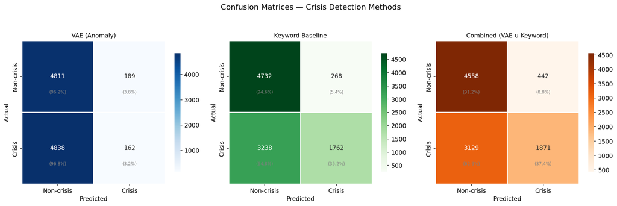

```
💾 Saved: ..\data\processed\evaluation\crisis_confusion_matrices.png
```

```python
from sklearn.metrics import confusion_matrix

fig, axes = plt.subplots(1, 3, figsize=(16, 5))
titles = ["VAE (Anomaly)", "Keyword Baseline", "Combined (VAE ∪ Keyword)"]
preds_list = [y_vae, y_kw, y_combined]
cmaps = ["Blues", "Greens", "Oranges"]

for ax, title, y_p, cmap in zip(axes, titles, preds_list, cmaps):
    cm = confusion_matrix(y_true, y_p)
    # Normalize to show rates
    cm_norm = cm.astype(float) / cm.sum(axis=1, keepdims=True)

    sns.heatmap(cm, annot=True, fmt="d", cmap=cmap, ax=ax,
                xticklabels=["Non-crisis", "Crisis"],
                yticklabels=["Non-crisis", "Crisis"],
                linewidths=1, linecolor="white", square=True,
                cbar_kws={"shrink": 0.7})

    # Add percentages as secondary annotations
    for i in range(2):
        for j in range(2):
            ax.text(j + 0.5, i + 0.72, f"({cm_norm[i, j]:.1%})",
                    ha="center", va="center", fontsize=8, color="gray")

    ax.set_xlabel("Predicted")
    ax.set_ylabel("Actual")
    ax.set_title(title, fontsize=11)

fig.suptitle("Confusion Matrices — Crisis Detection Methods", fontsize=14, y=1.02)
fig.tight_layout()
fig.savefig(OUTPUT_DIR / "crisis_confusion_matrices.png", dpi=200, bbox_inches="tight")
plt.show()
print(f"💾 Saved: {OUTPUT_DIR / 'crisis_confusion_matrices.png'}")
```

### Figure 4: VAE Threshold Sensitivity Analysis

How do precision, recall, and F1 change as we sweep the threshold?

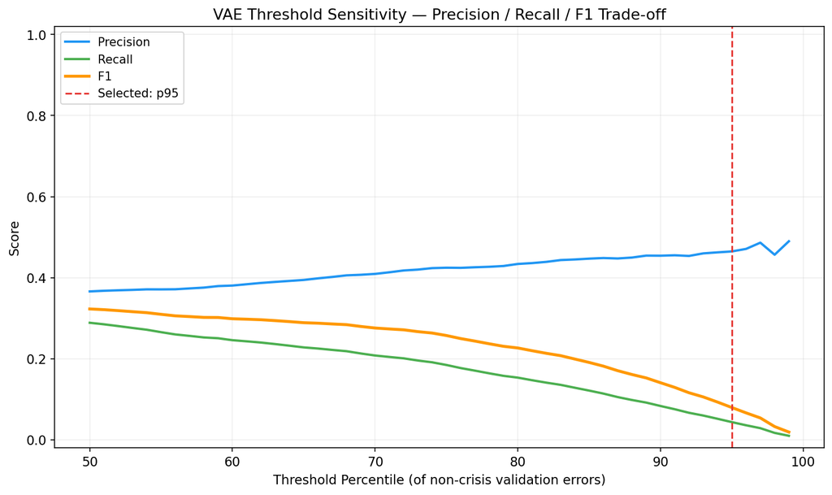

```
💾 Saved: ..\data\processed\evaluation\crisis_threshold_sensitivity.png
```

```python
# Generate thresholds from error distribution
percentiles = np.arange(50, 100, 1)
all_nc_errors = errors[y_true == 0]  # non-crisis errors for percentile basis

sweep_results = []
for pct in percentiles:
    t = np.percentile(all_nc_errors, pct)
    preds = (errors >= t).astype(int)
    tp = int(((y_true == 1) & (preds == 1)).sum())
    fp = int(((y_true == 0) & (preds == 1)).sum())
    fn = int(((y_true == 1) & (preds == 0)).sum())
    p = tp / (tp + fp) if (tp + fp) > 0 else 0
    r = tp / (tp + fn) if (tp + fn) > 0 else 0
    f = 2 * p * r / (p + r) if (p + r) > 0 else 0
    sweep_results.append({"percentile": pct, "threshold": t, "precision": p, "recall": r, "f1": f})

sweep_df = pd.DataFrame(sweep_results)

fig, ax = plt.subplots(figsize=(10, 6))
ax.plot(sweep_df["percentile"], sweep_df["precision"], label="Precision",
        linewidth=2, color="#2196F3", marker="", linestyle="-")
ax.plot(sweep_df["percentile"], sweep_df["recall"], label="Recall",
        linewidth=2, color="#4CAF50", marker="", linestyle="-")
ax.plot(sweep_df["percentile"], sweep_df["f1"], label="F1",
        linewidth=2.5, color="#FF9800", marker="", linestyle="-")

# Mark the chosen threshold
chosen_pct = summary["threshold"]["percentile"]
ax.axvline(chosen_pct, color="#E53935", linestyle="--", linewidth=1.5,
           label=f"Selected: p{chosen_pct}")

ax.set_xlabel("Threshold Percentile (of non-crisis validation errors)")
ax.set_ylabel("Score")
ax.set_title("VAE Threshold Sensitivity — Precision / Recall / F1 Trade-off")
ax.set_ylim(-0.02, 1.02)
ax.legend(fontsize=10)
ax.grid(alpha=0.2)
fig.tight_layout()
fig.savefig(OUTPUT_DIR / "crisis_threshold_sensitivity.png", dpi=200, bbox_inches="tight")
plt.show()
print(f"💾 Saved: {OUTPUT_DIR / 'crisis_threshold_sensitivity.png'}")
```

### Figure 5: Dual Detection Analysis (Venn-Style)

How do VAE and keyword detections overlap? Does combining them improve safety?

```
Total crisis samples: 5,000
VAE only caught:     109
Keyword only caught: 1,709
Both caught:         53
Neither caught:      3,129
```

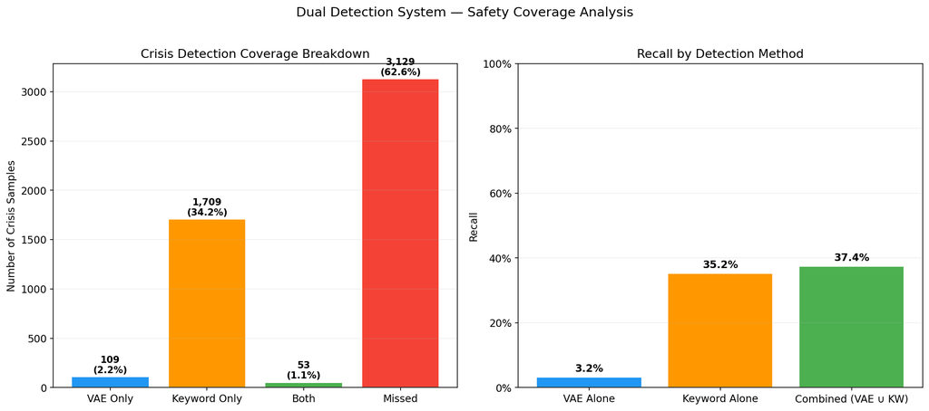

```
💾 Saved: ..\data\processed\evaluation\crisis_dual_detection_analysis.png
```

```python
# Crisis samples detected by each method
crisis_mask = y_true == 1
vae_caught = set(np.where((crisis_mask) & (y_vae == 1))[0])
kw_caught = set(np.where((crisis_mask) & (y_kw == 1))[0])
total_crisis = int(crisis_mask.sum())

both = vae_caught & kw_caught
vae_only = vae_caught - kw_caught
kw_only = kw_caught - vae_caught
neither = total_crisis - len(vae_caught | kw_caught)

print(f"Total crisis samples: {total_crisis:,}")
print(f"VAE only caught:     {len(vae_only):,}")
print(f"Keyword only caught: {len(kw_only):,}")
print(f"Both caught:         {len(both):,}")
print(f"Neither caught:      {neither:,}")

# Stacked bar chart showing detection coverage
fig, axes = plt.subplots(1, 2, figsize=(14, 6))

# Left: Detection breakdown
categories = ["VAE Only", "Keyword Only", "Both", "Missed"]
values = [len(vae_only), len(kw_only), len(both), neither]
colors = ["#2196F3", "#FF9800", "#4CAF50", "#F44336"]

bars = axes[0].bar(categories, values, color=colors, edgecolor="white", linewidth=1)
for bar, val in zip(bars, values):
    axes[0].text(bar.get_x() + bar.get_width()/2., bar.get_height() + 20,
                 f"{val:,}\n({val/total_crisis:.1%})",
                 ha="center", va="bottom", fontsize=10, fontweight="bold")
axes[0].set_ylabel("Number of Crisis Samples")
axes[0].set_title("Crisis Detection Coverage Breakdown")
axes[0].grid(axis="y", alpha=0.2)

# Right: Cumulative recall comparison
methods_data = [
    ("VAE Alone", len(vae_caught) / total_crisis),
    ("Keyword Alone", len(kw_caught) / total_crisis),
    ("Combined (VAE ∪ KW)", len(vae_caught | kw_caught) / total_crisis),
]
m_names = [d[0] for d in methods_data]
m_recalls = [d[1] for d in methods_data]
bar_colors = ["#2196F3", "#FF9800", "#4CAF50"]

bars2 = axes[1].bar(m_names, m_recalls, color=bar_colors, edgecolor="white", linewidth=1)
for bar, val in zip(bars2, m_recalls):
    axes[1].text(bar.get_x() + bar.get_width()/2., bar.get_height() + 0.01,
                 f"{val:.1%}", ha="center", va="bottom", fontsize=11, fontweight="bold")
axes[1].set_ylabel("Recall")
axes[1].set_title("Recall by Detection Method")
axes[1].set_ylim(0, 1.0)
axes[1].yaxis.set_major_formatter(mticker.PercentFormatter(1.0))
axes[1].grid(axis="y", alpha=0.2)

fig.suptitle("Dual Detection System — Safety Coverage Analysis", fontsize=14, y=1.02)
fig.tight_layout()
fig.savefig(OUTPUT_DIR / "crisis_dual_detection_analysis.png", dpi=200, bbox_inches="tight")
plt.show()
print(f"💾 Saved: {OUTPUT_DIR / 'crisis_dual_detection_analysis.png'}")
```

### Figure 6: Error Percentile Analysis (Box Plots)

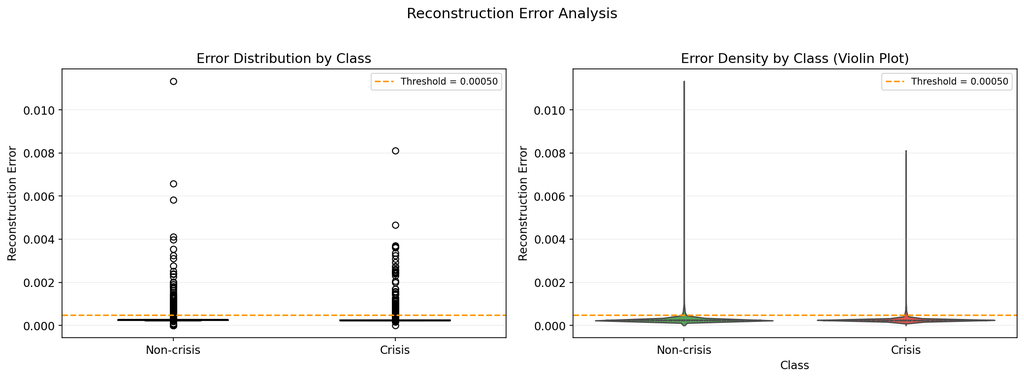

```
💾 Saved: ..\data\processed\evaluation\crisis_error_analysis.png
```

```python
fig, axes = plt.subplots(1, 2, figsize=(14, 5))

# Box plot
box_data = [non_crisis_errors, crisis_errors]
bp = axes[0].boxplot(box_data, labels=["Non-crisis", "Crisis"],
                     patch_artist=True, widths=0.5,
                     medianprops={"color": "black", "linewidth": 2})
bp["boxes"][0].set_facecolor("#4CAF50")
bp["boxes"][0].set_alpha(0.7)
bp["boxes"][1].set_facecolor("#F44336")
bp["boxes"][1].set_alpha(0.7)
axes[0].axhline(threshold, color="#FF9800", linestyle="--", linewidth=1.5,
                label=f"Threshold = {threshold:.5f}")
axes[0].set_ylabel("Reconstruction Error")
axes[0].set_title("Error Distribution by Class")
axes[0].legend(fontsize=9)
axes[0].grid(axis="y", alpha=0.2)

# Violin plot for richer density view
plot_df = pd.DataFrame({
    "Reconstruction Error": errors,
    "Class": ["Crisis" if c == 1 else "Non-crisis" for c in y_true]
})
sns.violinplot(data=plot_df, x="Class", y="Reconstruction Error",
               palette={"Non-crisis": "#4CAF50", "Crisis": "#F44336"},
               inner="quartile", ax=axes[1], cut=0)
axes[1].axhline(threshold, color="#FF9800", linestyle="--", linewidth=1.5,
                label=f"Threshold = {threshold:.5f}")
axes[1].set_title("Error Density by Class (Violin Plot)")
axes[1].legend(fontsize=9)
axes[1].grid(axis="y", alpha=0.2)

fig.suptitle("Reconstruction Error Analysis", fontsize=14, y=1.02)
fig.tight_layout()
fig.savefig(OUTPUT_DIR / "crisis_error_analysis.png", dpi=200, bbox_inches="tight")
plt.show()
print(f"💾 Saved: {OUTPUT_DIR / 'crisis_error_analysis.png'}")
```

### Figure 7: Error Statistics Table

```python
stats_data = []
for label, err_vals in [("Non-crisis", non_crisis_errors), ("Crisis", crisis_errors)]:
    stats_data.append({
        "Class": label,
        "Count": len(err_vals),
        "Mean": f"{np.mean(err_vals):.6f}",
        "Std": f"{np.std(err_vals):.6f}",
        "Median": f"{np.median(err_vals):.6f}",
        "P25": f"{np.percentile(err_vals, 25):.6f}",
        "P75": f"{np.percentile(err_vals, 75):.6f}",
        "P95": f"{np.percentile(err_vals, 95):.6f}",
        "Max": f"{np.max(err_vals):.6f}",
    })

stats_df = pd.DataFrame(stats_data)
print("\n📊 Reconstruction Error Statistics:")
display(stats_df)

stats_df.to_csv(OUTPUT_DIR / "crisis_error_statistics.csv", index=False)
print(f"\n💾 Saved: {OUTPUT_DIR / 'crisis_error_statistics.csv'}")
```

```
📊 Reconstruction Error Statistics:
```

|  | Class | Count | Mean | Std | Median | P25 | P75 | P95 | Max |
| --- | --- | --- | --- | --- | --- | --- | --- | --- | --- |
| 0 | Non-crisis | 5000 | 0.000286 | 0.000266 | 0.000247 | 0.000241 | 0.000258 | 0.000430 | 0.011340 |
| 1 | Crisis | 5000 | 0.000278 | 0.000228 | 0.000243 | 0.000237 | 0.000250 | 0.000397 | 0.008122 |

```
💾 Saved: ..\data\processed\evaluation\crisis_error_statistics.csv
```

## 5. Discussion & Interpretation

### Implications for the Report

- **Honest evaluation**: Don't hide the VAE's poor standalone recall — present it as a finding about the limitations of TF-IDF-based anomaly detection for semantic tasks
- **Safety argument**: The dual detection approach is a deliberate design choice. Frame it as responsible AI engineering
- **Future work**: Suggest using sentence-level embeddings (e.g., BERT CLS token) instead of TF-IDF for the VAE input, which would likely improve semantic separation

### For the Report — Recommended Figures

- **Figure 1** (error distribution): shows why VAE struggles — distributions overlap
- **Figure 2** (method comparison): clear headline result
- **Figure 3** (confusion matrices): detailed classification performance
- **Figure 5** (dual detection): justifies the safety-first design decision

```python
# Save complete evaluation summary
eval_summary = {
    "threshold": threshold,
    "threshold_percentile": summary["threshold"]["percentile"],
    "vae_metrics": {k: float(v) for k, v in compute_metrics(y_true, y_vae, "VAE").items() if isinstance(v, (int, float))},
    "keyword_metrics": {k: float(v) for k, v in compute_metrics(y_true, y_kw, "Keyword").items() if isinstance(v, (int, float))},
    "combined_metrics": {k: float(v) for k, v in compute_metrics(y_true, y_combined, "Combined").items() if isinstance(v, (int, float))},
    "detection_overlap": {
        "vae_only": len(vae_only),
        "keyword_only": len(kw_only),
        "both": len(both),
        "neither": neither,
        "total_crisis": total_crisis,
    },
    "figures_saved": [
        "crisis_error_distribution.png",
        "crisis_method_comparison.png",
        "crisis_confusion_matrices.png",
        "crisis_threshold_sensitivity.png",
        "crisis_dual_detection_analysis.png",
        "crisis_error_analysis.png",
    ]
}
(OUTPUT_DIR / "crisis_full_evaluation.json").write_text(
    json.dumps(eval_summary, indent=2)
)

print("\n" + "=" * 60)
print("🛡️ CRISIS EVALUATION COMPLETE")
print("=" * 60)
for m in ["VAE", "Keyword", "Combined"]:
    row = results[results["Method"].str.contains(m)].iloc[0]
    print(f"{m:12s} — P: {row['Precision']:.4f}, R: {row['Recall']:.4f}, F1: {row['F1']:.4f}")
print(f"\n6 figures + 2 CSVs + 1 JSON saved to: {OUTPUT_DIR}")
print("=" * 60)
```

```
============================================================
🛡️ CRISIS EVALUATION COMPLETE
============================================================
VAE          — P: 0.4615, R: 0.0324, F1: 0.0605
Keyword      — P: 0.8680, R: 0.3524, F1: 0.5013
Combined     — P: 0.8089, R: 0.3742, F1: 0.5117

6 figures + 2 CSVs + 1 JSON saved to: ..\data\processed\evaluation
============================================================
```